# Project 2: Comcast Telecom Consumer Complaints.

DESCRIPTION

Comcast is an American global telecommunication company. The firm has been providing terrible customer service. They continue to fall short despite repeated promises to improve. Only last month (October 2016) the authority fined them a $2.3 million, after receiving over 1000 consumer complaints.

The existing database will serve as a repository of public customer complaints filed against Comcast. It will help to pin down what is wrong with Comcast’s customer service.

Data Dictionary

Ticket #: Ticket number assigned to each complaint Customer Complaint: Description of complaint Date: Date of complaint Time: Time of complaint Received Via: Mode of communication of the complaint City: Customer city State: Customer state Zipcode: Customer zip Status: Status of complaint Filing on behalf of someone Analysis Task

- Import data into R environment.
- Provide the trend chart for the number of complaints at monthly and daily granularity levels.
- Provide a table with the frequency of complaint types.

Which complaint types are maximum i.e., around internet, network issues, or across any other domains. - Create a new categorical variable with value as Open and Closed. Open & Pending is to be categorized as Open and Closed & Solved is to be categorized as Closed. - Provide state wise status of complaints in a stacked bar chart. Use the categorized variable from Q3. Provide insights on:

Which state has the maximum complaints Which state has the highest percentage of unresolved complaints - Provide the percentage of complaints resolved till date, which were received through theInternet and customer care calls.

The analysis results to be provided with insights wherever applicable.

Solution

**- Set the working directory**

```r
setwd("C:/Users/ujuay/Desktop/Jupyter Notes/Simplilearn")
```

**- Confirm the working directory**

```r
getwd()
```

```
[1] "C:/Users/ujuay/Desktop/Jupyter Notes/Simplilearn"
```

**- install packages and load libraries**

```r
#install.packages("dplyr")
#install.packages("tidyselect")
#install.packages("ggpubr", type="win.binary")
library(stringi)
library(lubridate)
library(dplyr)
library(ggplot2)
library(ggpubr)
```

Q1. Import data into R environment

```r
comcast_data<- read.csv("Comcast Telecom Complaints data.csv",header = TRUE)
```

**- Manipulating column names**

```r
names(comcast_data)<- stri_replace_all(regex =  "\\.",replacement = "",str =names(comcast_data))
head(comcast_data)
```

|  | Ticket | CustomerComplaint | Date | Time | ReceivedVia | City | State | Zipcode | Status | FilingonBehalfofSomeone |
| --- | --- | --- | --- | --- | --- | --- | --- | --- | --- | --- |
| 1 | 250635 | Comcast Cable Internet Speeds | 22-04-2015 | 3:53:50 PM | Customer Care Call | Abingdon | Maryland | 21009 | Closed | No |
| 2 | 223441 | Payment disappear - service got disconnected | 4/8/2015 | 10:22:56 AM | Internet | Acworth | Georgia | 30102 | Closed | No |
| 3 | 242732 | Speed and Service | 18-04-2015 | 9:55:47 AM | Internet | Acworth | Georgia | 30101 | Closed | Yes |
| 4 | 277946 | Comcast Imposed a New Usage Cap of 300GB that punishes streaming. | 5/7/2015 | 11:59:35 AM | Internet | Acworth | Georgia | 30101 | Open | Yes |
| 5 | 307175 | Comcast not working and no service to boot | 26-05-2015 | 1:25:26 PM | Internet | Acworth | Georgia | 30101 | Solved | No |
| 6 | 338519 | ISP Charging for arbitrary data limits with overage fees | 6/12/2015 | 9:59:40 PM | Internet | Acworth | Georgia | 30101 | Solved | No |

**- Find NA values in the dataset**

```r
na_vector <- is.na(comcast_data)
length(na_vector[na_vector==T])
```

```
[1] 0
```

0 shows that there is no NA value in dataset

**- Convert the date values from character class to Date:**

```r
comcast_data$Date<- dmy(comcast_data$Date)
```

Q2.Provide the trend chart for the number of complaints at monthly and daily granularity levels

**- Extracting the Monthly and Daily Ticket Counts**

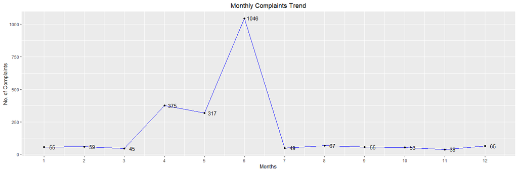

```r
monthly_count<- summarise(group_by(comcast_data,Month =as.integer(month(Date))),Count = n())
daily_count<- summarise(group_by(comcast_data,Date),Count =n())
monthly_count<-arrange(monthly_count,Month)


# Comparing the Monthly and Daily Complaints:

ggplot(data = monthly_count,aes(Month,Count,label = Count))+
  geom_line(color="blue")+
  geom_point()+
  geom_text(label= monthly_count$Count, nudge_x = 0.2, nudge_y = 0.8, check_overlap = T)+
  scale_x_continuous(breaks = monthly_count$Month)+
  labs(title = "Monthly Complaints Trend",x= "Months",y ="No. of Complaints")+
  theme(plot.title = element_text(hjust = 0.5))
```

The number of compliants in June were relatively higher than in other months. There may have been a major issue in June.

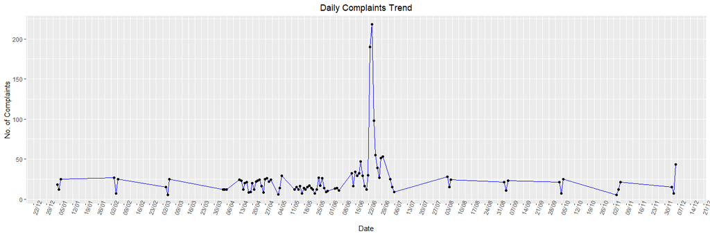

```r
ggplot(data = daily_count,aes(as.POSIXct(Date),Count))+
  geom_line(color="blue")+
  geom_point(size = 1.5)+
  scale_x_datetime(breaks = "1 weeks",date_labels = "%d/%m")+
  labs(title = "Daily Complaints Trend",x= "Date",y ="No. of Complaints")+
  theme(axis.text.x = element_text(angle = 70),
    plot.title = element_text(hjust = 0.5))
```

**- Complaint Type Processing**

```r
network_tickets<- contains(comcast_data$CustomerComplaint,match = 'network',ignore.case = T)
internet_tickets<- contains(comcast_data$CustomerComplaint,match = 'internet',ignore.case = T)
billing_tickets<- contains(comcast_data$CustomerComplaint,match = 'bill',ignore.case = T)
email_tickets<- contains(comcast_data$CustomerComplaint,match = 'email',ignore.case = T)
charges_ticket<- contains(comcast_data$CustomerComplaint,match = 'charge',ignore.case = T)

comcast_data$ComplaintType[internet_tickets]<- "Internet"
comcast_data$ComplaintType[network_tickets]<- "Network"
comcast_data$ComplaintType[billing_tickets]<- "Billing"
comcast_data$ComplaintType[email_tickets]<- "Email"
comcast_data$ComplaintType[charges_ticket]<- "Charges"

comcast_data$ComplaintType[-c(internet_tickets,network_tickets,
                              billing_tickets,charges_ticket,email_tickets)]<- "Others"
```

Q3.Provide a table with the frequency of complaint types.

```r
table(comcast_data$ComplaintType)
```

```
 Billing  Charges    Email Internet  Network   Others
     363      139       16      472        1     1233
```

There are different complaint types/categories which was combines into ‘Others’.

Q4. Which complaint types are maximum i.e., around internet, network issues, or across any other domains.

**The maximum compliant type is related to INTERNET**

Q5.Create a new categorical variable with value as Open and Closed. Open & Pending is to be categorized as Open and Closed & Solved is to be categorized as Closed.

**- Creating a new variable complaint_status with open and closed values**

```r
open_complaints<- (comcast_data$Status == "Open"| comcast_data$Status =="Pending")
closed_complaints<-(comcast_data$Status == "Closed"| comcast_data$Status =="Solved")
comcast_data$complaint_status[ open_complaints]<-"Open"
comcast_data$complaint_status[closed_complaints]<- "Closed"
```

Q6.Provide state wise status of complaints in a stacked bar chart. Use the categorized variable from Q3.

**- Creating a Stacked barchart for complaints based on State and Status:**

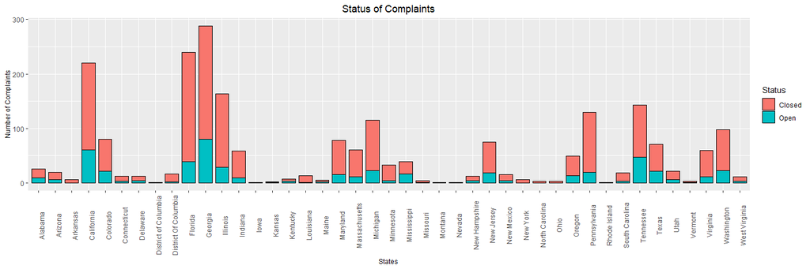

```r
comcast_data<- group_by(comcast_data,State,complaint_status)
chart_data<- summarise(comcast_data,Count = n())
ggplot(as.data.frame(chart_data) ,mapping = aes(State,Count))+
  geom_col(aes(fill = complaint_status),color='black',width = 0.8)+
  theme(axis.text.x = element_text(angle = 90),
        axis.title.y = element_text(size = 9),
        axis.title.x = element_text(size = 9),
        title = element_text(size = 11,colour = "black"),
        plot.title = element_text(hjust =  0.5))+
  labs(title = "Status of Complaints",
       x = "States",y = "Number of Complaints",
       fill= "Status")
```

Q7.Which state has the maximum complaints? The highest number of complaints were received from the state of Georgia.

Q8.Which state has the highest percentage of unresolved complaints? To find the state with higest number of unresolved complaints:

```r
chart_data%>%
  filter(complaint_status == "Open")->
  open_complaints
open_complaints[open_complaints$Count == max(open_complaints$Count),c(1,3)]
```

| State | Count |
| --- | --- |
| Georgia | 80 |

The state with the maximum number of unresolved complaints is Georgia with 80 unresolved complaints.

Q9. Provide the percentage of complaints resolved till date, which were received through the Internet and customer care calls.

**- Calculating the resolution percentage based on total and category:**

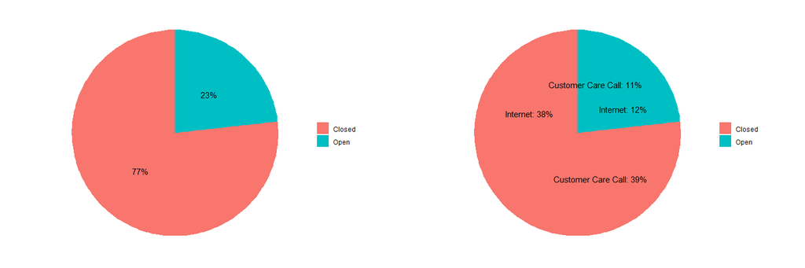

```r
resolved_data <- group_by(comcast_data,complaint_status)
total_resolved<- summarise(resolved_data,percentage =(n()/nrow(resolved_data)))
resolved_data <- group_by(comcast_data,ReceivedVia,complaint_status)
category_resolved<- summarise(resolved_data ,percentage =(n()/nrow(resolved_data)))
# Plotting the total complaints resolved
par(mfrow = c(1,2))
total<-ggplot(total_resolved,
              aes(x= "",y =percentage,fill = complaint_status))+
  geom_bar(stat = "identity",width = 1)+
  coord_polar("y",start = 0)+
  geom_text(aes(label = paste0(round(percentage*100),"%")),
            position = position_stack(vjust = 0.5))+
  labs(x = NULL,y = NULL,fill = NULL)+
  theme_classic()+theme(axis.line = element_blank(),
                        axis.text = element_blank(),
                        axis.ticks = element_blank())

# Plotting the Category based complaints Status
category<-ggplot(category_resolved,
                 aes(x= "",y =percentage,fill = complaint_status))+
  geom_bar(stat = "identity",width = 1)+
  coord_polar("y",start = 0)+
  geom_text(aes(label = paste0(ReceivedVia,": ",round(percentage*100),"%")),
            position = position_stack(vjust = 0.5))+
  labs(x = NULL,y = NULL,fill = NULL)+
  theme_classic()+theme(axis.line = element_blank(),
                        axis.text = element_blank(),
                        axis.ticks = element_blank())
ggarrange(total,category,nrow = 1, ncol = 2)
```

**Insights:**